# Part I - (Prosper Loan Analysis)

## by (Adeniran Kayode)

## Introduction

## Preliminary Wrangling

> This document explores a dataset containing 113,937 loans with 81 variables on each loan, including loan amount, borrower rate (or interest rate), current loan status, borrower income, and many others.

> Load in your dataset and describe its properties through the questions below. Try and motivate your exploration goals through this section.

|  | ListingKey | ListingNumber | ListingCreationDate | CreditGrade | Term | LoanStatus | ClosedDate | BorrowerAPR | BorrowerRate | LenderYield | ... | LP_ServiceFees | LP_CollectionFees | LP_GrossPrincipalLoss | LP_NetPrincipalLoss | LP_NonPrincipalRecoverypayments | PercentFunded | Recommendations | InvestmentFromFriendsCount | InvestmentFromFriendsAmount | Investors |
| --- | --- | --- | --- | --- | --- | --- | --- | --- | --- | --- | --- | --- | --- | --- | --- | --- | --- | --- | --- | --- | --- |
| 0 | 1021339766868145413AB3B | 193129 | 2007-08-26 19:09:29.263000000 | C | 36 | Completed | 2009-08-14 00:00:00 | 0.16516 | 0.1580 | 0.1380 | ... | -133.18 | 0.0 | 0.0 | 0.0 | 0.0 | 1.0 | 0 | 0 | 0.0 | 258 |
| 1 | 10273602499503308B223C1 | 1209647 | 2014-02-27 08:28:07.900000000 | NaN | 36 | Current | NaN | 0.12016 | 0.0920 | 0.0820 | ... | 0.00 | 0.0 | 0.0 | 0.0 | 0.0 | 1.0 | 0 | 0 | 0.0 | 1 |
| 2 | 0EE9337825851032864889A | 81716 | 2007-01-05 15:00:47.090000000 | HR | 36 | Completed | 2009-12-17 00:00:00 | 0.28269 | 0.2750 | 0.2400 | ... | -24.20 | 0.0 | 0.0 | 0.0 | 0.0 | 1.0 | 0 | 0 | 0.0 | 41 |
| 3 | 0EF5356002482715299901A | 658116 | 2012-10-22 11:02:35.010000000 | NaN | 36 | Current | NaN | 0.12528 | 0.0974 | 0.0874 | ... | -108.01 | 0.0 | 0.0 | 0.0 | 0.0 | 1.0 | 0 | 0 | 0.0 | 158 |
| 4 | 0F023589499656230C5E3E2 | 909464 | 2013-09-14 18:38:39.097000000 | NaN | 36 | Current | NaN | 0.24614 | 0.2085 | 0.1985 | ... | -60.27 | 0.0 | 0.0 | 0.0 | 0.0 | 1.0 | 0 | 0 | 0.0 | 20 |

5 rows × 81 columns

### What is the structure of your dataset?

> My dataset consist of 113937 loans with 81 features.

### What is/are the main feature(s) of interest in your dataset?

> The main feature of interest for me will be the BorrowerAPR.

### What features in the dataset do you think will help support your investigation into your feature(s) of interest?

> Features to support my investigations include Term  
> LoanStatus  
> BorrowerAPR  
> BorrowerRate  
> LenderYield  
> EstimatedEffectiveYield  
> EstimatedLoss  
> EstimatedReturn  
> ProsperRating (Alpha)  
> ProsperScore  
> ListingCategory (numeric)  
> BorrowerState  
> Occupation  
> EmploymentStatus  
> StatedMonthlyIncome LoanOriginalAmount LoanStatus

```
0
```

```
0
```

## Univariate Exploration

> In this section, investigate distributions of individual variables. If you see unusual points or outliers, take a deeper look to clean things up and prepare yourself to look at relationships between variables.

> **Rubric Tip**: The project (Parts I alone) should have at least 15 visualizations distributed over univariate, bivariate, and multivariate plots to explore many relationships in the data set. Use reasoning to justify the flow of the exploration.

> **Rubric Tip**: Use the "Question-Visualization-Observations" framework throughout the exploration. This framework involves **asking a question from the data, creating a visualization to find answers, and then recording observations after each visualisation.**

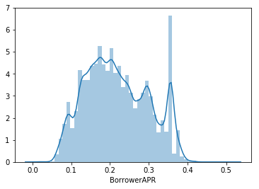

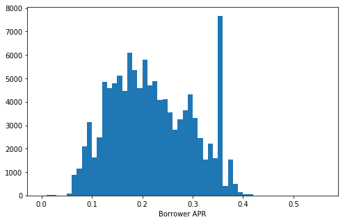

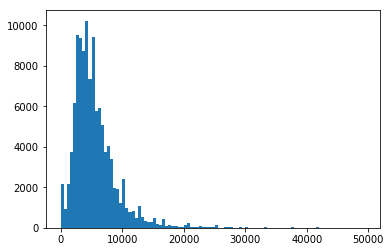

The monthly income chat is right screwed most of the income are less than 30k dollars.

|  | LoanOriginalAmount | BorrowerAPR | StatedMonthlyIncome | Term | ProsperRating (Alpha) | LoanStatus | BorrowerRate | ProsperScore | EmploymentStatus | EstimatedLoss | BorrowerState | Occupation | EstimatedEffectiveYield | LenderYield | ProsperRating (numeric) | EstimatedReturn |
| --- | --- | --- | --- | --- | --- | --- | --- | --- | --- | --- | --- | --- | --- | --- | --- | --- |
| 8066 | 2000 | 0.35643 | 4.166667e+05 | 36 | HR | Completed | 0.3199 | 4.0 | Employed | 0.1830 | IL | Police Officer/Correction Officer | 0.29170 | 0.3099 | 1.0 | 0.10870 |
| 8870 | 12500 | 0.12700 | 2.083333e+05 | 36 | NaN | Chargedoff | 0.1200 | 6.0 | Not available | 0.0724 | CT | Other | 0.10085 | 0.1050 | 4.0 | 0.02845 |
| 17411 | 7500 | 0.35643 | 4.833333e+05 | 36 | E | Completed | 0.3199 | 5.0 | Employed | 0.1470 | HI | Professional | 0.29570 | 0.3099 | 2.0 | 0.14870 |
| 35218 | 1000 | 0.07389 | 1.083333e+05 | 36 | AA | Completed | 0.0705 | 10.0 | Full-time | 0.0060 | VA | Attorney | 0.05450 | 0.0605 | 7.0 | 0.05450 |
| 45028 | 4000 | 0.33973 | 1.500000e+05 | 36 | E | Current | 0.2999 | 2.0 | Self-employed | 0.1490 | KS | Nurse (RN) | 0.27660 | 0.2899 | 2.0 | 0.12760 |
| 53014 | 4000 | 0.25785 | 6.185478e+05 | 12 | D | Completed | 0.1795 | 3.0 | Self-employed | 0.0975 | CA | Other | 0.15590 | 0.1695 | 3.0 | 0.05840 |
| 53167 | 4000 | 0.35797 | 1.750003e+06 | 36 | HR | Current | 0.3177 | 4.0 | Self-employed | 0.1650 | OR | Professional | 0.28960 | 0.3077 | 1.0 | 0.12460 |
| 56867 | 25000 | 0.11144 | 1.850818e+05 | 36 | NaN | Completed | 0.1045 | 6.0 | Self-employed | 0.0724 | NC | Other | 0.08535 | 0.0995 | 4.0 | 0.01295 |
| 57133 | 4000 | 0.35643 | 4.666667e+05 | 36 | E | Current | 0.3199 | 5.0 | Employed | 0.1470 | CT | Other | 0.29570 | 0.3099 | 2.0 | 0.14870 |
| 59298 | 15000 | 0.24246 | 1.208333e+05 | 36 | C | Current | 0.2049 | 6.0 | Self-employed | 0.0890 | CT | Other | 0.19040 | 0.1949 | 4.0 | 0.10140 |
| 63925 | 2000 | 0.25948 | 1.404167e+05 | 36 | NaN | Completed | 0.2500 | 6.0 | Not available | 0.0724 | NaN | Retail Management | 0.23085 | 0.2450 | 4.0 | 0.15845 |
| 78431 | 5000 | 0.20253 | 1.033341e+05 | 36 | NaN | Chargedoff | 0.1952 | 6.0 | Full-time | 0.0724 | NaN | Executive | 0.17605 | 0.1852 | 4.0 | 0.10365 |
| 80075 | 25000 | 0.20217 | 1.583333e+05 | 36 | C | Current | 0.1655 | 6.0 | Employed | 0.0674 | FL | Attorney | 0.14559 | 0.1555 | 4.0 | 0.07819 |
| 82831 | 4000 | 0.31012 | 2.500000e+05 | 36 | E | Current | 0.2710 | 3.0 | Self-employed | 0.1275 | WA | Other | 0.24910 | 0.2610 | 2.0 | 0.12160 |
| 83697 | 5000 | 0.08684 | 1.850818e+05 | 36 | NaN | Completed | 0.0800 | 6.0 | Not available | 0.0724 | NC | Other | 0.06085 | 0.0750 | 4.0 | -0.01155 |
| 111265 | 12765 | 0.20593 | 1.087500e+05 | 60 | B | Completed | 0.1819 | 9.0 | Employed | 0.0599 | NY | Executive | 0.16190 | 0.1719 | 5.0 | 0.10200 |
| 113270 | 2000 | 0.22712 | 3.944000e+05 | 36 | C | Current | 0.1899 | 6.0 | Employed | 0.0724 | CA | Other | 0.16790 | 0.1799 | 4.0 | 0.09550 |

Less than 0.3 percent borrowers have stated monthly income greater than 30k, these can be seemed as outlier for the following analysis, so it is better to remove borrower records with income greater than 30k.

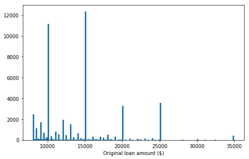

They are high increase between 10k, 15k, 20k ,25k and 35k , but they are relatively low loans for 30k. They are also spikes between 8k, 9k ad 14k.

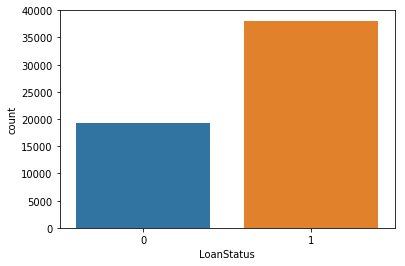

```
(0.66376109203117095, 0.33623890796882905)
```

So, in the historical data as a whole, 66.37% of loans are completed. 33.62% of loans "defaulted". (During analysis, one should always bear in mind that default as we've defined it includes charge-offs, cancellations, and even any current loans with late payments. It might be more constructive to think of the loans labelled with a 0 as "bad" loans rather than outright "defaults").

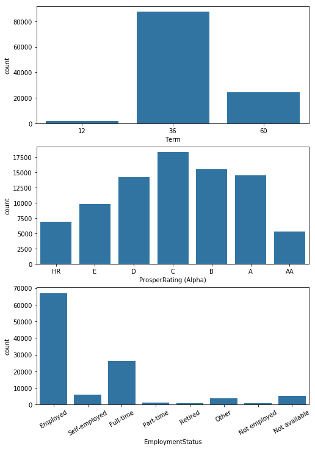

> **Rubric Tip**: Visualizations should depict the data appropriately so that the plots are easily interpretable. You should choose an appropriate plot type, data encodings, and formatting as needed. The formatting may include setting/adding the title, labels, legend, and comments. Also, do not overplot or incorrectly plot ordinal data.

### Discuss the distribution(s) of your variable(s) of interest. Were there any unusual points? Did you need to perform any transformations?

> Borrower APR rate is quiet multimodal, most of the values are at the range of 0.05 and 0.4. There are no unusual points.

### Of the features you investigated, were there any unusual distributions? Did you perform any operations on the data to tidy, adjust, or change the form of the data? If so, why did you do this?

> The distributions of stated monthly income is highly right screwed. Most stated monthly incomes are less than 30k, but some of them are incredibly high, like greater than 100k. Surprisingly, most of borrowers with greater than 100k monthly income only loan less than 5k dollars. So, the very large stated monthly income may be made up. Overall, Less than 0.3 percent borrowers have stated monthly income greater than 30k, these can be seemed as outlier for the following analysis, so it is better to remove borrower records with income greater than 30k. The common term for loans is also 36 and it is clerly seen that number of employed persons taking loans are also high with fulltime taking the stage.

There is no need to perform any transformations.

## Bivariate Exploration

> In this section, investigate relationships between pairs of variables in your data. Make sure the variables that you cover here have been introduced in some fashion in the previous section (univariate exploration).

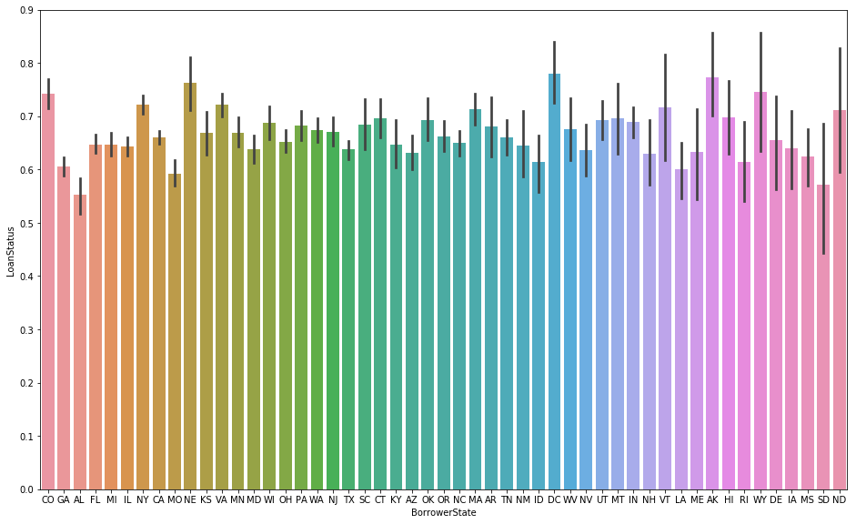

```
(0.35310472659870251, 0.36246518105849579)
```

Lets us get some numeric and categoricl variables to work with , by first getting their correlations.

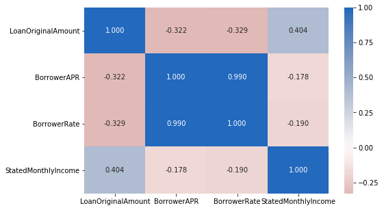

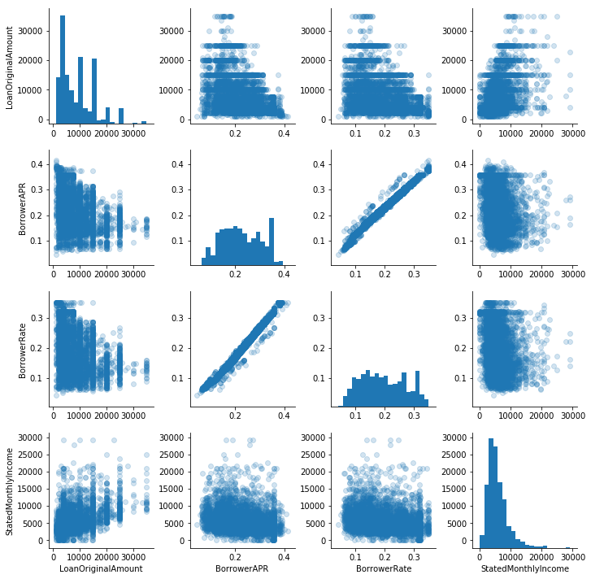

Let's move on to looking at how borrower APR, stated monthly income and loan original amount correlate with the categorical variables.

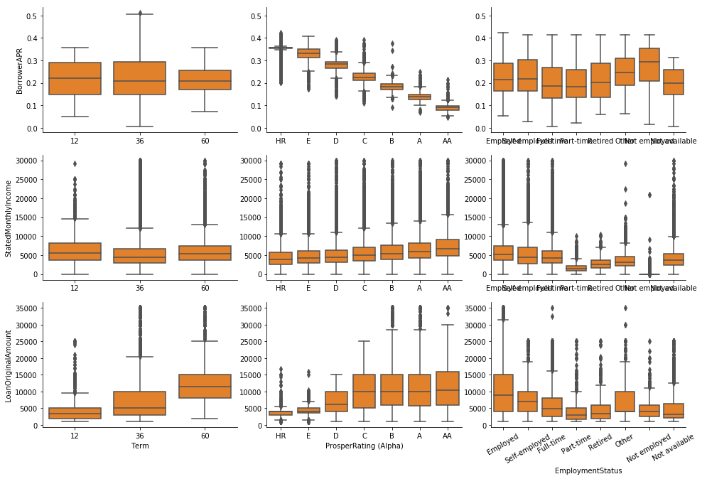

The figure shows that the loan amount is increased with the increase of loan term. The borrower APR decreases with the better rating. Borrowers with the best Prosper ratings have the lowest APR. It means that the Prosper rating has a strong effect on borrower APR. Borrowers with better rating also have larger monthly income and loan amount. Employed, self-employed and full time borrowers have more monthly income and loan amount than part-time, retired and not employed borrowers.

Finally, let's look at relationships between the three categorical features.

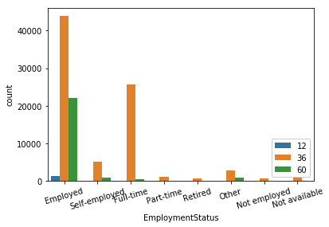

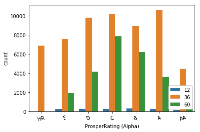

The employment status variable do not have enough data on part-time, retired and not employed borrowers to show its interaction with term and Prosper rating variables. But we can see that there is a interaction between term and Prosper rating. Proportionally, there are more 60 month loans on B and C ratings. There is only 36 months loans for HR rating borrowers.

### Talk about some of the relationships you observed in this part of the investigation. How did the feature(s) of interest vary with other features in the dataset?

> The borrower APR is negatively associated with the loan original amount, which mean the more the loan amount, the lower the APR. It also shows that at different size of the loan amount, the APR has a large range, but the range of APR decrease with the increase of loan amount. The Prosper rating also has a strong effect on the borrower APR, which decreases with the better rating.

### Did you observe any interesting relationships between the other features (not the main feature(s) of interest)?

> The loan original amount is positively correlated with the stated monthly income, it makes sense since borrowers with more monthly income could loan more money. It also shows that borrowers with better rating also have larger monthly income and loan amount. There is a interaction between prosper rating and term. Proportionally, there are more 60 month loans on B and C ratings. There is only 36 months loans for HR rating borrowers.

## Multivariate Exploration

> Create plots of three or more variables to investigate your data even further. Make sure that your investigations are justified, and follow from your work in the previous sections.

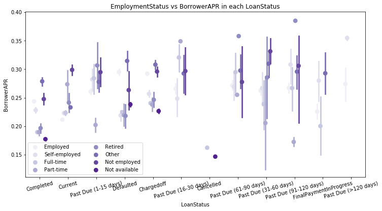

Loans that are past generally tend to have a high increase in interest rate. While others tend to maintain a proper rate until they are defaulted or past.

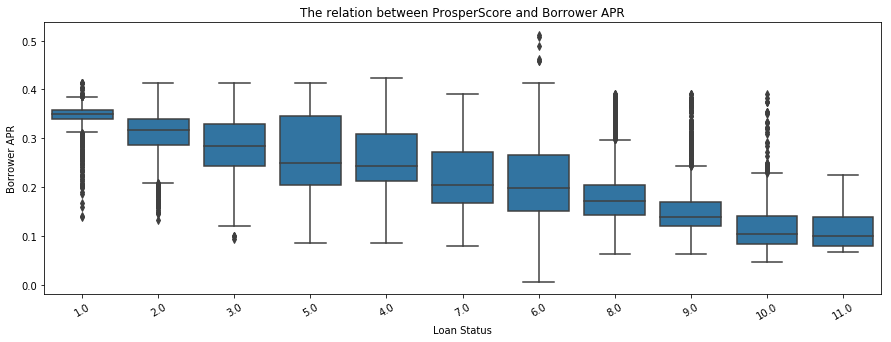

The better the prosper score the more tendency tou are to get a loan with a good borroer APR

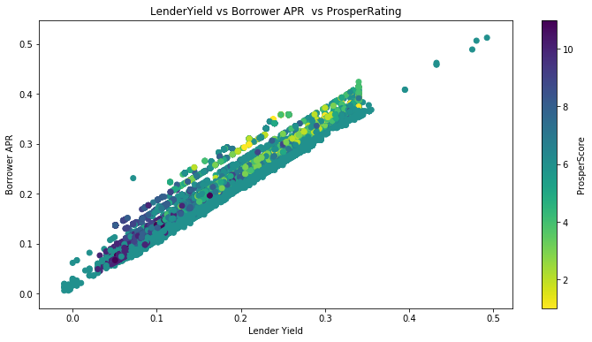

The Borrower APR and Lender yield have a strong positive correlation such that when the interest borrowers pays more , the lender yield will increase. The higher the prosper score lower will lower borrower apr and this makes the lender yield low too.

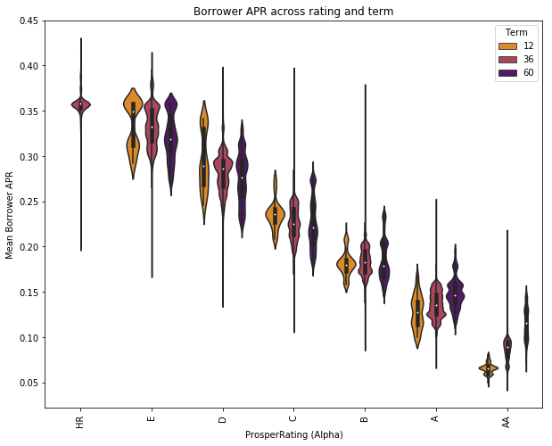

We can deduce that the borrower APR decrease with the increase in the terms for people with HR-C raings. But for people with B-AA ratings, the APR increase with the increase of borrow term.

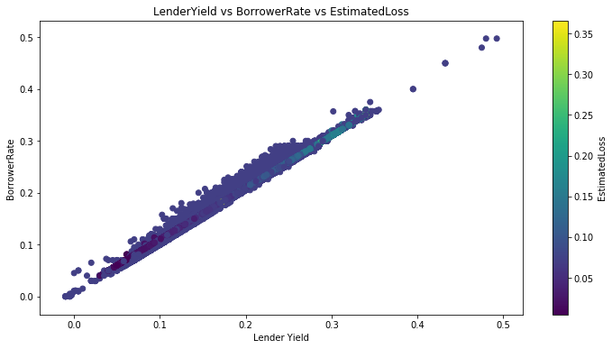

There is a strong correlation pattern between the lender yield and the borrower rate but the estimated loss variable has a less common data with this two(They are less common).

### Talk about some of the relationships you observed in this part of the investigation. Were there features that strengthened each other in terms of looking at your feature(s) of interest?

### Were there any interesting or surprising interactions between features?

Loans that are past generally tend to have a high increase in interest rate. While others tend to maintain a proper rate until they are defaulted or past. The Borrower APR and Lender yield have a strong positive correlation such that when the interest borrowers pays more , the lender yield will increase. The higher the prosper score lower will lower borrower apr and this makes the lender yield low too. There is a strong correlation pattern between the lender yield and the borrower rate but the estimated loss variable has a less common data with this two(They are less common).

## Conclusions

> You can write a summary of the main findings and reflect on the steps taken during the data exploration.

References: Kaggle.com